# Unicorn_Winery_Analysis

```python
#import required library for our projects..
import numpy as np
import pandas as pd
from time import time
from IPython.display import display # Allows the use of display() for displaying DataFrames

import matplotlib.pyplot as plt
import seaborn as sns

# Import supplementary visualization code vpython from project root folder
from vpython import *
#import vpython as vs
#import visuals as vs

# Pretty display for notebooks
%matplotlib inline

from scipy.stats import kurtosis, skew
```

### Usage of these libraries:

numpy is a package in python that is used for scientific computing. It supports higher-order mathematical functions, higher dimensional arrays, matrices and other data structures. pandas is a very popular library that is used for a lot of data analysis and statistics related problems. time - standard module in python that allows for time related functions display is a module in the IPython toolkit that helps you display data structures in a nice, readable format. matplotlib is a very popular visualization library that lets you create a wide array of figures, charts and graphs in the IPython Notebook seaborn is another visualization tool that uses matplotlib underneath, and provides you with easy-to-use APIs for visualization. It also makes your graphs more prettier!

```python
data_path = 'Case_Onsite_Modeling_Wine/wine_dataset.csv'
WineDataDetails = pd.read_csv(data_path)
df=pd.DataFrame(WineDataDetails)
df
```

|  | fixed_acidity | volatile_acidity | citric_acid | residual_sugar | chlorides | free_sulfur_dioxide | total_sulfur_dioxide | density | pH | sulphates | alcohol | quality | style |
| --- | --- | --- | --- | --- | --- | --- | --- | --- | --- | --- | --- | --- | --- |
| 0 | 7.4 | 0.700 | 0.00 | 1.90 | 0.076 | 11.0 | 34.0 | 0.99780 | 3.51 | 0.56 | 9.400000 | 5 | red |
| 1 | 7.8 | 0.880 | 0.00 | 2.60 | 0.098 | 25.0 | 67.0 | 0.99680 | 3.20 | 0.68 | 9.800000 | 5 | red |
| 2 | 7.8 | 0.760 | 0.04 | 2.30 | 0.092 | 15.0 | 54.0 | 0.99700 | 3.26 | 0.65 | 9.800000 | 5 | red |
| 3 | 11.2 | 0.280 | 0.56 | 1.90 | 0.075 | 17.0 | 60.0 | 0.99800 | 3.16 | 0.58 | 9.800000 | 6 | red |
| 4 | 7.4 | 0.700 | 0.00 | 1.90 | 0.076 | 11.0 | 34.0 | 0.99780 | 3.51 | 0.56 | 9.400000 | 5 | red |
| 5 | 7.4 | 0.660 | 0.00 | 1.80 | 0.075 | 13.0 | 40.0 | 0.99780 | 3.51 | 0.56 | 9.400000 | 5 | red |
| 6 | 7.9 | 0.600 | 0.06 | 1.60 | 0.069 | 15.0 | 59.0 | 0.99640 | 3.30 | 0.46 | 9.400000 | 5 | red |
| 7 | 7.3 | 0.650 | 0.00 | 1.20 | 0.065 | 15.0 | 21.0 | 0.99460 | 3.39 | 0.47 | 10.000000 | 7 | red |
| 8 | 7.8 | 0.580 | 0.02 | 2.00 | 0.073 | 9.0 | 18.0 | 0.99680 | 3.36 | 0.57 | 9.500000 | 7 | red |
| 9 | 7.5 | 0.500 | 0.36 | 6.10 | 0.071 | 17.0 | 102.0 | 0.99780 | 3.35 | 0.80 | 10.500000 | 5 | red |
| 10 | 6.7 | 0.580 | 0.08 | 1.80 | 0.097 | 15.0 | 65.0 | 0.99590 | 3.28 | 0.54 | 9.200000 | 5 | red |
| 11 | 7.5 | 0.500 | 0.36 | 6.10 | 0.071 | 17.0 | 102.0 | 0.99780 | 3.35 | 0.80 | 10.500000 | 5 | red |
| 12 | 5.6 | 0.615 | 0.00 | 1.60 | 0.089 | 16.0 | 59.0 | 0.99430 | 3.58 | 0.52 | 9.900000 | 5 | red |
| 13 | 7.8 | 0.610 | 0.29 | 1.60 | 0.114 | 9.0 | 29.0 | 0.99740 | 3.26 | 1.56 | 9.100000 | 5 | red |
| 14 | 8.9 | 0.620 | 0.18 | 3.80 | 0.176 | 52.0 | 145.0 | 0.99860 | 3.16 | 0.88 | 9.200000 | 5 | red |
| 15 | 8.9 | 0.620 | 0.19 | 3.90 | 0.170 | 51.0 | 148.0 | 0.99860 | 3.17 | 0.93 | 9.200000 | 5 | red |
| 16 | 8.5 | 0.280 | 0.56 | 1.80 | 0.092 | 35.0 | 103.0 | 0.99690 | 3.30 | 0.75 | 10.500000 | 7 | red |
| 17 | 8.1 | 0.560 | 0.28 | 1.70 | 0.368 | 16.0 | 56.0 | 0.99680 | 3.11 | 1.28 | 9.300000 | 5 | red |
| 18 | 7.4 | 0.590 | 0.08 | 4.40 | 0.086 | 6.0 | 29.0 | 0.99740 | 3.38 | 0.50 | 9.000000 | 4 | red |
| 19 | 7.9 | 0.320 | 0.51 | 1.80 | 0.341 | 17.0 | 56.0 | 0.99690 | 3.04 | 1.08 | 9.200000 | 6 | red |
| 20 | 8.9 | 0.220 | 0.48 | 1.80 | 0.077 | 29.0 | 60.0 | 0.99680 | 3.39 | 0.53 | 9.400000 | 6 | red |
| 21 | 7.6 | 0.390 | 0.31 | 2.30 | 0.082 | 23.0 | 71.0 | 0.99820 | 3.52 | 0.65 | 9.700000 | 5 | red |
| 22 | 7.9 | 0.430 | 0.21 | 1.60 | 0.106 | 10.0 | 37.0 | 0.99660 | 3.17 | 0.91 | 9.500000 | 5 | red |
| 23 | 8.5 | 0.490 | 0.11 | 2.30 | 0.084 | 9.0 | 67.0 | 0.99680 | 3.17 | 0.53 | 9.400000 | 5 | red |
| 24 | 6.9 | 0.400 | 0.14 | 2.40 | 0.085 | 21.0 | 40.0 | 0.99680 | 3.43 | 0.63 | 9.700000 | 6 | red |
| 25 | 6.3 | 0.390 | 0.16 | 1.40 | 0.080 | 11.0 | 23.0 | 0.99550 | 3.34 | 0.56 | 9.300000 | 5 | red |
| 26 | 7.6 | 0.410 | 0.24 | 1.80 | 0.080 | 4.0 | 11.0 | 0.99620 | 3.28 | 0.59 | 9.500000 | 5 | red |
| 27 | 7.9 | 0.430 | 0.21 | 1.60 | 0.106 | 10.0 | 37.0 | 0.99660 | 3.17 | 0.91 | 9.500000 | 5 | red |
| 28 | 7.1 | 0.710 | 0.00 | 1.90 | 0.080 | 14.0 | 35.0 | 0.99720 | 3.47 | 0.55 | 9.400000 | 5 | red |
| 29 | 7.8 | 0.645 | 0.00 | 2.00 | 0.082 | 8.0 | 16.0 | 0.99640 | 3.38 | 0.59 | 9.800000 | 6 | red |
| ... | ... | ... | ... | ... | ... | ... | ... | ... | ... | ... | ... | ... | ... |
| 6467 | 5.8 | 0.230 | 0.31 | 4.50 | 0.046 | 42.0 | 124.0 | 0.99324 | 3.31 | 0.64 | 10.800000 | 6 | white |
| 6468 | 6.6 | 0.240 | 0.33 | 10.10 | 0.032 | 8.0 | 81.0 | 0.99626 | 3.19 | 0.51 | 9.800000 | 6 | white |
| 6469 | 6.1 | 0.320 | 0.28 | 6.60 | 0.021 | 29.0 | 132.0 | 0.99188 | 3.15 | 0.36 | 11.450000 | 7 | white |
| 6470 | 5.0 | 0.200 | 0.40 | 1.90 | 0.015 | 20.0 | 98.0 | 0.98970 | 3.37 | 0.55 | 12.050000 | 6 | white |
| 6471 | 6.0 | 0.420 | 0.41 | 12.40 | 0.032 | 50.0 | 179.0 | 0.99622 | 3.14 | 0.60 | 9.700000 | 5 | white |
| 6472 | 5.7 | 0.210 | 0.32 | 1.60 | 0.030 | 33.0 | 122.0 | 0.99044 | 3.33 | 0.52 | 11.900000 | 6 | white |
| 6473 | 5.6 | 0.200 | 0.36 | 2.50 | 0.048 | 16.0 | 125.0 | 0.99282 | 3.49 | 0.49 | 10.000000 | 6 | white |
| 6474 | 7.4 | 0.220 | 0.26 | 1.20 | 0.035 | 18.0 | 97.0 | 0.99245 | 3.12 | 0.41 | 9.700000 | 6 | white |
| 6475 | 6.2 | 0.380 | 0.42 | 2.50 | 0.038 | 34.0 | 117.0 | 0.99132 | 3.36 | 0.59 | 11.600000 | 7 | white |
| 6476 | 5.9 | 0.540 | 0.00 | 0.80 | 0.032 | 12.0 | 82.0 | 0.99286 | 3.25 | 0.36 | 8.800000 | 5 | white |
| 6477 | 6.2 | 0.530 | 0.02 | 0.90 | 0.035 | 6.0 | 81.0 | 0.99234 | 3.24 | 0.35 | 9.500000 | 4 | white |
| 6478 | 6.6 | 0.340 | 0.40 | 8.10 | 0.046 | 68.0 | 170.0 | 0.99494 | 3.15 | 0.50 | 9.533333 | 6 | white |
| 6479 | 6.6 | 0.340 | 0.40 | 8.10 | 0.046 | 68.0 | 170.0 | 0.99494 | 3.15 | 0.50 | 9.533333 | 6 | white |
| 6480 | 5.0 | 0.235 | 0.27 | 11.75 | 0.030 | 34.0 | 118.0 | 0.99540 | 3.07 | 0.50 | 9.400000 | 6 | white |
| 6481 | 5.5 | 0.320 | 0.13 | 1.30 | 0.037 | 45.0 | 156.0 | 0.99184 | 3.26 | 0.38 | 10.700000 | 5 | white |
| 6482 | 4.9 | 0.470 | 0.17 | 1.90 | 0.035 | 60.0 | 148.0 | 0.98964 | 3.27 | 0.35 | 11.500000 | 6 | white |
| 6483 | 6.5 | 0.330 | 0.38 | 8.30 | 0.048 | 68.0 | 174.0 | 0.99492 | 3.14 | 0.50 | 9.600000 | 5 | white |
| 6484 | 6.6 | 0.340 | 0.40 | 8.10 | 0.046 | 68.0 | 170.0 | 0.99494 | 3.15 | 0.50 | 9.550000 | 6 | white |
| 6485 | 6.2 | 0.210 | 0.28 | 5.70 | 0.028 | 45.0 | 121.0 | 0.99168 | 3.21 | 1.08 | 12.150000 | 7 | white |
| 6486 | 6.2 | 0.410 | 0.22 | 1.90 | 0.023 | 5.0 | 56.0 | 0.98928 | 3.04 | 0.79 | 13.000000 | 7 | white |
| 6487 | 6.8 | 0.220 | 0.36 | 1.20 | 0.052 | 38.0 | 127.0 | 0.99330 | 3.04 | 0.54 | 9.200000 | 5 | white |
| 6488 | 4.9 | 0.235 | 0.27 | 11.75 | 0.030 | 34.0 | 118.0 | 0.99540 | 3.07 | 0.50 | 9.400000 | 6 | white |
| 6489 | 6.1 | 0.340 | 0.29 | 2.20 | 0.036 | 25.0 | 100.0 | 0.98938 | 3.06 | 0.44 | 11.800000 | 6 | white |
| 6490 | 5.7 | 0.210 | 0.32 | 0.90 | 0.038 | 38.0 | 121.0 | 0.99074 | 3.24 | 0.46 | 10.600000 | 6 | white |
| 6491 | 6.5 | 0.230 | 0.38 | 1.30 | 0.032 | 29.0 | 112.0 | 0.99298 | 3.29 | 0.54 | 9.700000 | 5 | white |
| 6492 | 6.2 | 0.210 | 0.29 | 1.60 | 0.039 | 24.0 | 92.0 | 0.99114 | 3.27 | 0.50 | 11.200000 | 6 | white |
| 6493 | 6.6 | 0.320 | 0.36 | 8.00 | 0.047 | 57.0 | 168.0 | 0.99490 | 3.15 | 0.46 | 9.600000 | 5 | white |
| 6494 | 6.5 | 0.240 | 0.19 | 1.20 | 0.041 | 30.0 | 111.0 | 0.99254 | 2.99 | 0.46 | 9.400000 | 6 | white |
| 6495 | 5.5 | 0.290 | 0.30 | 1.10 | 0.022 | 20.0 | 110.0 | 0.98869 | 3.34 | 0.38 | 12.800000 | 7 | white |
| 6496 | 6.0 | 0.210 | 0.38 | 0.80 | 0.020 | 22.0 | 98.0 | 0.98941 | 3.26 | 0.32 | 11.800000 | 6 | white |

6497 rows × 13 columns

```python
red_wine=WineDataDetails[WineDataDetails['style'] == 'red']
red_wine.head()
```

|  | fixed_acidity | volatile_acidity | citric_acid | residual_sugar | chlorides | free_sulfur_dioxide | total_sulfur_dioxide | density | pH | sulphates | alcohol | quality | style |
| --- | --- | --- | --- | --- | --- | --- | --- | --- | --- | --- | --- | --- | --- |
| 0 | 7.4 | 0.70 | 0.00 | 1.9 | 0.076 | 11.0 | 34.0 | 0.9978 | 3.51 | 0.56 | 9.4 | 5 | red |
| 1 | 7.8 | 0.88 | 0.00 | 2.6 | 0.098 | 25.0 | 67.0 | 0.9968 | 3.20 | 0.68 | 9.8 | 5 | red |
| 2 | 7.8 | 0.76 | 0.04 | 2.3 | 0.092 | 15.0 | 54.0 | 0.9970 | 3.26 | 0.65 | 9.8 | 5 | red |
| 3 | 11.2 | 0.28 | 0.56 | 1.9 | 0.075 | 17.0 | 60.0 | 0.9980 | 3.16 | 0.58 | 9.8 | 6 | red |
| 4 | 7.4 | 0.70 | 0.00 | 1.9 | 0.076 | 11.0 | 34.0 | 0.9978 | 3.51 | 0.56 | 9.4 | 5 | red |

```python
white_wine=WineDataDetails[WineDataDetails['style'] == 'white']
white_wine.head()
```

|  | fixed_acidity | volatile_acidity | citric_acid | residual_sugar | chlorides | free_sulfur_dioxide | total_sulfur_dioxide | density | pH | sulphates | alcohol | quality | style |
| --- | --- | --- | --- | --- | --- | --- | --- | --- | --- | --- | --- | --- | --- |
| 1599 | 7.0 | 0.27 | 0.36 | 20.7 | 0.045 | 45.0 | 170.0 | 1.0010 | 3.00 | 0.45 | 8.8 | 6 | white |
| 1600 | 6.3 | 0.30 | 0.34 | 1.6 | 0.049 | 14.0 | 132.0 | 0.9940 | 3.30 | 0.49 | 9.5 | 6 | white |
| 1601 | 8.1 | 0.28 | 0.40 | 6.9 | 0.050 | 30.0 | 97.0 | 0.9951 | 3.26 | 0.44 | 10.1 | 6 | white |
| 1602 | 7.2 | 0.23 | 0.32 | 8.5 | 0.058 | 47.0 | 186.0 | 0.9956 | 3.19 | 0.40 | 9.9 | 6 | white |
| 1603 | 7.2 | 0.23 | 0.32 | 8.5 | 0.058 | 47.0 | 186.0 | 0.9956 | 3.19 | 0.40 | 9.9 | 6 | white |

```python
# store wine type as an attribute
red_wine=WineDataDetails[WineDataDetails['style'] == 'red']
white_wine=WineDataDetails[WineDataDetails['style'] == 'white']

# bucket wine quality scores into qualitative quality labels
red_wine['quality_label'] = red_wine['quality'].apply(lambda value: 'low'
                                                          if value <= 5 else 'medium'
                                                              if value <= 7 else 'high')
red_wine['quality_label'] = pd.Categorical(red_wine['quality_label'],
                                           categories=['low', 'medium', 'high'])
white_wine['quality_label'] = white_wine['quality'].apply(lambda value: 'low'
                                                              if value <= 5 else 'medium'
                                                                  if value <= 7 else 'high')
white_wine['quality_label'] = pd.Categorical(white_wine['quality_label'],
                                             categories=['low', 'medium', 'high'])

# merge red and white wine datasets
wines = pd.concat([red_wine, white_wine])

# re-shuffle records just to randomize data points
wines = wines.sample(frac=1, random_state=42).reset_index(drop=True)
```

[output not shown]

```python
# Display the first five records
#display(WineDataDetails.head(n=5))
```

```python
wines.head()
```

|  | fixed_acidity | volatile_acidity | citric_acid | residual_sugar | chlorides | free_sulfur_dioxide | total_sulfur_dioxide | density | pH | sulphates | alcohol | quality | style | quality_label |
| --- | --- | --- | --- | --- | --- | --- | --- | --- | --- | --- | --- | --- | --- | --- |
| 0 | 7.0 | 0.17 | 0.74 | 12.8 | 0.045 | 24.0 | 126.0 | 0.99420 | 3.26 | 0.38 | 12.2 | 8 | white | high |
| 1 | 7.7 | 0.64 | 0.21 | 2.2 | 0.077 | 32.0 | 133.0 | 0.99560 | 3.27 | 0.45 | 9.9 | 5 | red | low |
| 2 | 6.8 | 0.39 | 0.34 | 7.4 | 0.020 | 38.0 | 133.0 | 0.99212 | 3.18 | 0.44 | 12.0 | 7 | white | medium |
| 3 | 6.3 | 0.28 | 0.47 | 11.2 | 0.040 | 61.0 | 183.0 | 0.99592 | 3.12 | 0.51 | 9.5 | 6 | white | medium |
| 4 | 7.4 | 0.35 | 0.20 | 13.9 | 0.054 | 63.0 | 229.0 | 0.99888 | 3.11 | 0.50 | 8.9 | 6 | white | medium |

```python
# Display the last five records
#display(WineDataDetails.tail(n=5))
```

```python
wines.tail()
```

|  | fixed_acidity | volatile_acidity | citric_acid | residual_sugar | chlorides | free_sulfur_dioxide | total_sulfur_dioxide | density | pH | sulphates | alcohol | quality | style | quality_label |
| --- | --- | --- | --- | --- | --- | --- | --- | --- | --- | --- | --- | --- | --- | --- |
| 6492 | 7.6 | 0.32 | 0.58 | 16.75 | 0.050 | 43.0 | 163.0 | 0.99990 | 3.15 | 0.54 | 9.2 | 5 | white | low |
| 6493 | 5.6 | 0.28 | 0.27 | 3.90 | 0.043 | 52.0 | 158.0 | 0.99202 | 3.35 | 0.44 | 10.7 | 7 | white | medium |
| 6494 | 6.4 | 0.37 | 0.20 | 5.60 | 0.117 | 61.0 | 183.0 | 0.99459 | 3.24 | 0.43 | 9.5 | 5 | white | low |
| 6495 | 6.5 | 0.26 | 0.50 | 8.00 | 0.051 | 46.0 | 197.0 | 0.99536 | 3.18 | 0.47 | 9.5 | 5 | white | low |
| 6496 | 7.2 | 0.62 | 0.06 | 2.70 | 0.077 | 15.0 | 85.0 | 0.99746 | 3.51 | 0.54 | 9.5 | 5 | red | low |

# Exploratory Data Analysis and Visualizations

# Some basic preliminary analysis of our data:

```python
wines.isnull().any()
```

```
fixed_acidity           False
volatile_acidity        False
citric_acid             False
residual_sugar          False
chlorides               False
free_sulfur_dioxide     False
total_sulfur_dioxide    False
density                 False
pH                      False
sulphates               False
alcohol                 False
quality                 False
style                   False
quality_label           False
dtype: bool
```

# Examine the features in the data-set and their data types

```python
wines.info()
```

```
<class 'pandas.core.frame.DataFrame'>
RangeIndex: 6497 entries, 0 to 6496
Data columns (total 14 columns):
fixed_acidity           6497 non-null float64
volatile_acidity        6497 non-null float64
citric_acid             6497 non-null float64
residual_sugar          6497 non-null float64
chlorides               6497 non-null float64
free_sulfur_dioxide     6497 non-null float64
total_sulfur_dioxide    6497 non-null float64
density                 6497 non-null float64
pH                      6497 non-null float64
sulphates               6497 non-null float64
alcohol                 6497 non-null float64
quality                 6497 non-null int64
style                   6497 non-null object
quality_label           6497 non-null category
dtypes: category(1), float64(11), int64(1), object(1)
memory usage: 666.4+ KB
```

# Show comparitive parameters of Red and white wine

```python
subset_attributes = ['residual_sugar', 'total_sulfur_dioxide', 'sulphates', 'alcohol', 'volatile_acidity', 'quality']
rs = round(red_wine[subset_attributes].describe(),2)
ws = round(white_wine[subset_attributes].describe(),2)
pd.concat([rs, ws], axis=1, keys=['Red Wine Statistics', 'White Wine Statistics'])
```

|  | Red Wine Statistics residual_sugar | Red Wine Statistics total_sulfur_dioxide | Red Wine Statistics sulphates | Red Wine Statistics alcohol | Red Wine Statistics volatile_acidity | Red Wine Statistics quality | White Wine Statistics residual_sugar | White Wine Statistics total_sulfur_dioxide | White Wine Statistics sulphates | White Wine Statistics alcohol | White Wine Statistics volatile_acidity | White Wine Statistics quality |
| --- | --- | --- | --- | --- | --- | --- | --- | --- | --- | --- | --- | --- |
| count | 1599.00 | 1599.00 | 1599.00 | 1599.00 | 1599.00 | 1599.00 | 4898.00 | 4898.00 | 4898.00 | 4898.00 | 4898.00 | 4898.00 |
| mean | 2.54 | 46.47 | 0.66 | 10.42 | 0.53 | 5.64 | 6.39 | 138.36 | 0.49 | 10.51 | 0.28 | 5.88 |
| std | 1.41 | 32.90 | 0.17 | 1.07 | 0.18 | 0.81 | 5.07 | 42.50 | 0.11 | 1.23 | 0.10 | 0.89 |
| min | 0.90 | 6.00 | 0.33 | 8.40 | 0.12 | 3.00 | 0.60 | 9.00 | 0.22 | 8.00 | 0.08 | 3.00 |
| 25% | 1.90 | 22.00 | 0.55 | 9.50 | 0.39 | 5.00 | 1.70 | 108.00 | 0.41 | 9.50 | 0.21 | 5.00 |
| 50% | 2.20 | 38.00 | 0.62 | 10.20 | 0.52 | 6.00 | 5.20 | 134.00 | 0.47 | 10.40 | 0.26 | 6.00 |
| 75% | 2.60 | 62.00 | 0.73 | 11.10 | 0.64 | 6.00 | 9.90 | 167.00 | 0.55 | 11.40 | 0.32 | 6.00 |
| max | 15.50 | 289.00 | 2.00 | 14.90 | 1.58 | 8.00 | 65.80 | 440.00 | 1.08 | 14.20 | 1.10 | 9.00 |

```python
subset_attributes = ['alcohol', 'volatile_acidity', 'pH', 'quality']
ls = round(wines[wines['quality_label'] == 'low'][subset_attributes].describe(),2)
ms = round(wines[wines['quality_label'] == 'medium'][subset_attributes].describe(),2)
hs = round(wines[wines['quality_label'] == 'high'][subset_attributes].describe(),2)
pd.concat([ls, ms, hs], axis=1, keys=['Low Quality Wine', 'Medium Quality Wine', 'High Quality Wine'])
```

|  | Low Quality Wine alcohol | Low Quality Wine volatile_acidity | Low Quality Wine pH | Low Quality Wine quality | Medium Quality Wine alcohol | Medium Quality Wine volatile_acidity | Medium Quality Wine pH | Medium Quality Wine quality | High Quality Wine alcohol | High Quality Wine volatile_acidity | High Quality Wine pH | High Quality Wine quality |
| --- | --- | --- | --- | --- | --- | --- | --- | --- | --- | --- | --- | --- |
| count | 2384.00 | 2384.00 | 2384.00 | 2384.00 | 3915.00 | 3915.00 | 3915.00 | 3915.00 | 198.00 | 198.00 | 198.00 | 198.00 |
| mean | 9.87 | 0.40 | 3.21 | 4.88 | 10.81 | 0.31 | 3.22 | 6.28 | 11.69 | 0.29 | 3.23 | 8.03 |
| std | 0.84 | 0.19 | 0.16 | 0.36 | 1.20 | 0.14 | 0.16 | 0.45 | 1.27 | 0.12 | 0.16 | 0.16 |
| min | 8.00 | 0.10 | 2.74 | 3.00 | 8.40 | 0.08 | 2.72 | 6.00 | 8.50 | 0.12 | 2.88 | 8.00 |
| 25% | 9.30 | 0.26 | 3.11 | 5.00 | 9.80 | 0.21 | 3.11 | 6.00 | 11.00 | 0.21 | 3.13 | 8.00 |
| 50% | 9.60 | 0.34 | 3.20 | 5.00 | 10.80 | 0.27 | 3.21 | 6.00 | 12.00 | 0.28 | 3.23 | 8.00 |
| 75% | 10.40 | 0.50 | 3.31 | 5.00 | 11.70 | 0.36 | 3.33 | 7.00 | 12.60 | 0.35 | 3.33 | 8.00 |
| max | 14.90 | 1.58 | 3.90 | 5.00 | 14.20 | 1.04 | 4.01 | 7.00 | 14.00 | 0.85 | 3.72 | 9.00 |

# Inferential Statistics

```python
from scipy import stats

F, p = stats.f_oneway(wines[wines['quality_label'] == 'low']['alcohol'],
                      wines[wines['quality_label'] == 'medium']['alcohol'],
                      wines[wines['quality_label'] == 'high']['alcohol'])
print('ANOVA test for mean alcohol levels across wine samples with different quality ratings')
print('F Statistic:', F, '\tp-value:', p)

F, p = stats.f_oneway(wines[wines['quality_label'] == 'low']['pH'],
                      wines[wines['quality_label'] == 'medium']['pH'],
                      wines[wines['quality_label'] == 'high']['pH'])
print('\nANOVA test for mean pH levels across wine samples with different quality ratings')
print('F Statistic:', F, '\tp-value:', p)
```

```
ANOVA test for mean alcohol levels across wine samples with different quality ratings
F Statistic: 673.074534717 	p-value: 2.27153375689e-266

ANOVA test for mean pH levels across wine samples with different quality ratings
F Statistic: 1.23638608035 	p-value: 0.290500277977
```

```
Text(0,0.5,'Wine pH')
```

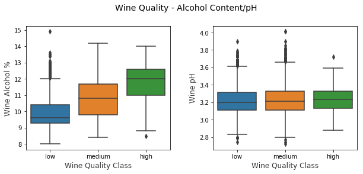

```python
f, (ax1, ax2) = plt.subplots(1, 2, figsize=(10, 4))
f.suptitle('Wine Quality - Alcohol Content/pH', fontsize=14)
f.subplots_adjust(top=0.85, wspace=0.3)

sns.boxplot(x="quality_label", y="alcohol",
            data=wines, ax=ax1)
ax1.set_xlabel("Wine Quality Class",size = 12,alpha=0.8)
ax1.set_ylabel("Wine Alcohol %",size = 12,alpha=0.8)

sns.boxplot(x="quality_label", y="pH", data=wines, ax=ax2)
ax2.set_xlabel("Wine Quality Class",size = 12,alpha=0.8)
ax2.set_ylabel("Wine pH",size = 12,alpha=0.8)
```

# Univariate Analysis

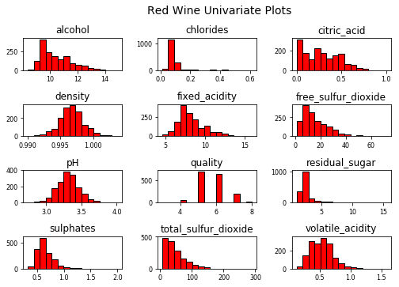

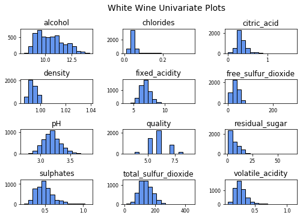

```python
red_wine.hist(bins=15, color='red', edgecolor='black', linewidth=1.0,
              xlabelsize=8, ylabelsize=8, grid=False)
plt.tight_layout(rect=(0, 0, 1.2, 1.2))
rt = plt.suptitle('Red Wine Univariate Plots', x=0.65, y=1.25, fontsize=14)

white_wine.hist(bins=15, color='cornflowerblue', edgecolor='black', linewidth=1.0,
              xlabelsize=8, ylabelsize=8, grid=False)
plt.tight_layout(rect=(0, 0, 1.2, 1.2))
wt = plt.suptitle('White Wine Univariate Plots', x=0.65, y=1.25, fontsize=14)
```

[figure not shown]

```python
df_plot = pd.DataFrame(wines) # Create a pandas DataFrame out of the numpy array
df_plot.plot.hist(alpha=0.5, bins=15, grid=True, legend=None)  # Pandas helper function to plot a hist. Uses matplotlib under the hood.
plt.xlabel("quality")
plt.title("Quality-Frequency-Histogram")
plt.show()
```

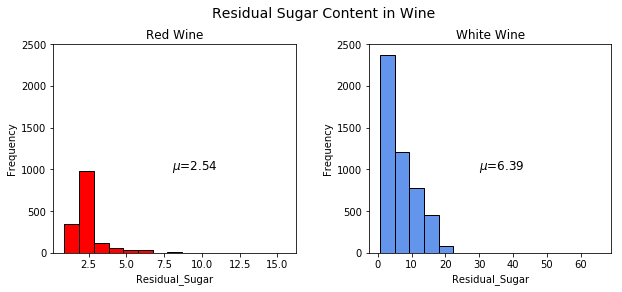

```python
fig = plt.figure(figsize = (10,4))
title = fig.suptitle("Residual Sugar Content in Wine", fontsize=14)
fig.subplots_adjust(top=0.85, wspace=0.3)

ax1 = fig.add_subplot(1,2, 1)
ax1.set_title("Red Wine")
ax1.set_xlabel("Residual_Sugar")
ax1.set_ylabel("Frequency")
ax1.set_ylim([0, 2500])
ax1.text(8, 1000, r'$\mu$='+str(round(red_wine['residual_sugar'].mean(),2)),
         fontsize=12)
r_freq, r_bins, r_patches = ax1.hist(red_wine['residual_sugar'], color='red', bins=15,
                                    edgecolor='black', linewidth=1)

ax2 = fig.add_subplot(1,2, 2)
ax2.set_title("White Wine")
ax2.set_xlabel("Residual_Sugar")
ax2.set_ylabel("Frequency")
ax2.set_ylim([0, 2500])
ax2.text(30, 1000, r'$\mu$='+str(round(white_wine['residual_sugar'].mean(),2)),
         fontsize=12)
w_freq, w_bins, w_patches = ax2.hist(white_wine['residual_sugar'], color='cornflowerblue', bins=15,
                                    edgecolor='black', linewidth=1)
```

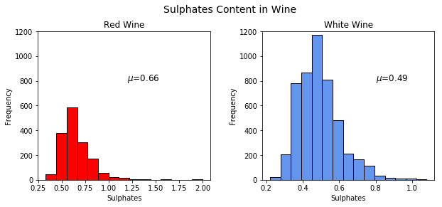

```python
fig = plt.figure(figsize = (10,4))
title = fig.suptitle("Sulphates Content in Wine", fontsize=14)
fig.subplots_adjust(top=0.85, wspace=0.3)

ax1 = fig.add_subplot(1,2, 1)
ax1.set_title("Red Wine")
ax1.set_xlabel("Sulphates")
ax1.set_ylabel("Frequency")
ax1.set_ylim([0, 1200])
ax1.text(1.2, 800, r'$\mu$='+str(round(red_wine['sulphates'].mean(),2)),
         fontsize=12)
r_freq, r_bins, r_patches = ax1.hist(red_wine['sulphates'], color='red', bins=15,
                                    edgecolor='black', linewidth=1)

ax2 = fig.add_subplot(1,2, 2)
ax2.set_title("White Wine")
ax2.set_xlabel("Sulphates")
ax2.set_ylabel("Frequency")
ax2.set_ylim([0, 1200])
ax2.text(0.8, 800, r'$\mu$='+str(round(white_wine['sulphates'].mean(),2)),
         fontsize=12)
w_freq, w_bins, w_patches = ax2.hist(white_wine['sulphates'], color='cornflowerblue', bins=15,
                                    edgecolor='black', linewidth=1)
```

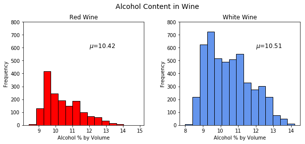

```python
fig = plt.figure(figsize = (10,4))
title = fig.suptitle("Alcohol Content in Wine", fontsize=14)
fig.subplots_adjust(top=0.85, wspace=0.3)

ax1 = fig.add_subplot(1,2, 1)
ax1.set_title("Red Wine")
ax1.set_xlabel("Alcohol % by Volume")
ax1.set_ylabel("Frequency")
ax1.set_ylim([0, 800])
ax1.text(12, 600, r'$\mu$='+str(round(red_wine['alcohol'].mean(),2)),
         fontsize=12)
r_freq, r_bins, r_patches = ax1.hist(red_wine['alcohol'], color='red', bins=15,
                                    edgecolor='black', linewidth=1)

ax2 = fig.add_subplot(1,2, 2)
ax2.set_title("White Wine")
ax2.set_xlabel("Alcohol % by Volume")
ax2.set_ylabel("Frequency")
ax2.set_ylim([0, 800])
ax2.text(12, 600, r'$\mu$='+str(round(white_wine['alcohol'].mean(),2)),
         fontsize=12)
w_freq, w_bins, w_patches = ax2.hist(white_wine['alcohol'], color='cornflowerblue', bins=15,
                                    edgecolor='black', linewidth=1)
```

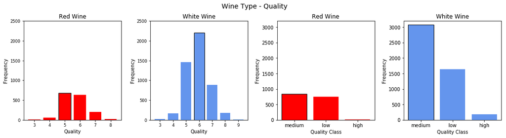

```python
fig = plt.figure(figsize = (18, 4))
title = fig.suptitle("Wine Type - Quality", fontsize=14)
fig.subplots_adjust(top=0.85, wspace=0.3)

ax1 = fig.add_subplot(1,4, 1)
ax1.set_title("Red Wine")
ax1.set_xlabel("Quality")
ax1.set_ylabel("Frequency")
rw_q = red_wine['quality'].value_counts()
rw_q = (list(rw_q.index), list(rw_q.values))
ax1.set_ylim([0, 2500])
ax1.tick_params(axis='both', which='major', labelsize=8.5)
bar1 = ax1.bar(rw_q[0], rw_q[1], color='red',
        edgecolor='black', linewidth=1)


ax2 = fig.add_subplot(1,4, 2)
ax2.set_title("White Wine")
ax2.set_xlabel("Quality")
ax2.set_ylabel("Frequency")
ww_q = white_wine['quality'].value_counts()
ww_q = (list(ww_q.index), list(ww_q.values))
ax2.set_ylim([0, 2500])
ax2.tick_params(axis='both', which='major', labelsize=8.5)
bar2 = ax2.bar(ww_q[0], ww_q[1], color='cornflowerblue',
        edgecolor='black', linewidth=1)

ax3 = fig.add_subplot(1,4, 3)
ax3.set_title("Red Wine")
ax3.set_xlabel("Quality Class")
ax3.set_ylabel("Frequency")
rw_q = red_wine['quality_label'].value_counts()
rw_q = (list(rw_q.index), list(rw_q.values))
ax3.set_ylim([0, 3200])
bar3 = ax3.bar(list(range(len(rw_q[0]))), rw_q[1], color='red',
        edgecolor='black', linewidth=1, tick_label =rw_q[0])

ax4 = fig.add_subplot(1,4, 4)
ax4.set_title("White Wine")
ax4.set_xlabel("Quality Class")
ax4.set_ylabel("Frequency")
ww_q = white_wine['quality_label'].value_counts()
ww_q = (list(ww_q.index), list(ww_q.values))
ax4.set_ylim([0, 3200])
bar4 = ax4.bar(list(range(len(ww_q[0]))), ww_q[1], color='cornflowerblue',
        edgecolor='black', linewidth=1, tick_label =ww_q[0])
```

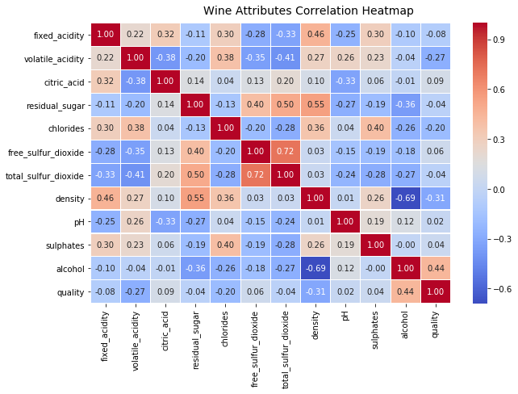

```python
f, ax = plt.subplots(figsize=(10, 6))
corr = wines.corr()
hm = sns.heatmap(round(corr,2), annot=True, ax=ax, cmap="coolwarm",fmt='.2f',
            linewidths=.05)
f.subplots_adjust(top=0.93)
t= f.suptitle('Wine Attributes Correlation Heatmap', fontsize=14)
```

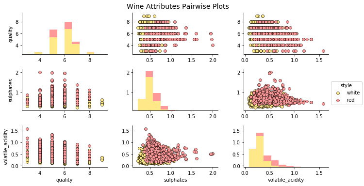

```python
cols = ['style', 'quality', 'sulphates', 'volatile_acidity']
pp = sns.pairplot(wines[cols], hue='style', size=1.8, aspect=1.8,
                  palette={"red": "#FF9999", "white": "#FFE888"},
                  plot_kws=dict(edgecolor="black", linewidth=0.5))
fig = pp.fig
fig.subplots_adjust(top=0.93, wspace=0.3)
t = fig.suptitle('Wine Attributes Pairwise Plots', fontsize=14)
```

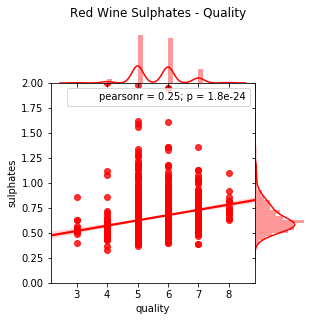

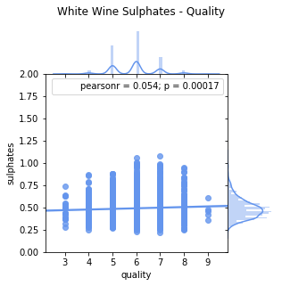

```python
rj = sns.jointplot(x='quality', y='sulphates', data=red_wine,
                   kind='reg', ylim=(0, 2),
                   color='red', space=0, size=4.5, ratio=4)
rj.ax_joint.set_xticks(list(range(3,9)))
fig = rj.fig
fig.subplots_adjust(top=0.9)
t = fig.suptitle('Red Wine Sulphates - Quality', fontsize=12)

wj = sns.jointplot(x='quality', y='sulphates', data=white_wine,
                   kind='reg', ylim=(0, 2),
                   color='cornflowerblue', space=0, size=4.5, ratio=4)
wj.ax_joint.set_xticks(list(range(3,10)))
fig = wj.fig
fig.subplots_adjust(top=0.9)
t = fig.suptitle('White Wine Sulphates - Quality', fontsize=12)
```

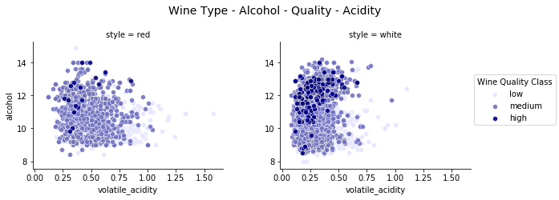

```python
g = sns.FacetGrid(wines, col="style", hue='quality_label',
                  col_order=['red', 'white'], hue_order=['low', 'medium', 'high'],
                  aspect=1.2, size=3.5, palette=sns.light_palette('navy', 3))
g.map(plt.scatter, "volatile_acidity", "alcohol", alpha=0.9,
      edgecolor='white', linewidth=0.5)
fig = g.fig
fig.subplots_adjust(top=0.8, wspace=0.3)
fig.suptitle('Wine Type - Alcohol - Quality - Acidity', fontsize=14)
l = g.add_legend(title='Wine Quality Class')
```

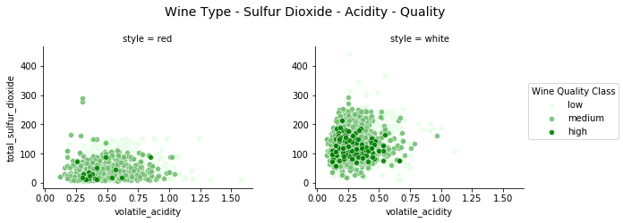

```python
g = sns.FacetGrid(wines, col="style", hue='quality_label',
                  col_order=['red', 'white'], hue_order=['low', 'medium', 'high'],
                  aspect=1.2, size=3.5, palette=sns.light_palette('green', 3))
g.map(plt.scatter, "volatile_acidity", "total_sulfur_dioxide", alpha=0.9,
      edgecolor='white', linewidth=0.5)
fig = g.fig
fig.subplots_adjust(top=0.8, wspace=0.3)
fig.suptitle('Wine Type - Sulfur Dioxide - Acidity - Quality', fontsize=14)
l = g.add_legend(title='Wine Quality Class')
```

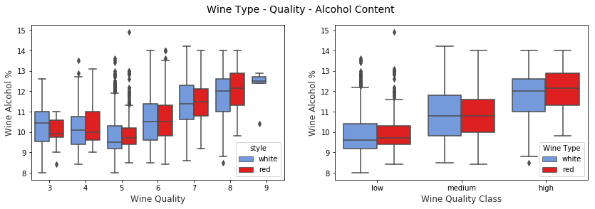

```python
f, (ax1, ax2) = plt.subplots(1, 2, figsize=(14, 4))
f.suptitle('Wine Type - Quality - Alcohol Content', fontsize=14)

sns.boxplot(x="quality", y="alcohol", hue="style",
               data=wines, palette={"red": "r", "white": "cornflowerblue"}, ax=ax1)
ax1.set_xlabel("Wine Quality",size = 12,alpha=0.8)
ax1.set_ylabel("Wine Alcohol %",size = 12,alpha=0.8)

sns.boxplot(x="quality_label", y="alcohol", hue="style",
               data=wines, palette={"red": "r", "white": "cornflowerblue"}, ax=ax2)
ax2.set_xlabel("Wine Quality Class",size = 12,alpha=0.8)
ax2.set_ylabel("Wine Alcohol %",size = 12,alpha=0.8)
l = plt.legend(loc='best', title='Wine Type')
```

[figure not shown]

```python
f, (ax1, ax2) = plt.subplots(1, 2, figsize=(14, 4))
f.suptitle('Wine Type - Quality - Acidity', fontsize=14)

sns.violinplot(x="quality", y="volatile_acidity", hue="style",
               data=wines, split=True, inner="quart", linewidth=1.3,
               palette={"red": "r", "white": "cornflowerblue"}, ax=ax1)
ax1.set_xlabel("Wine Quality",size = 12,alpha=0.8)
ax1.set_ylabel("Wine Fixed Acidity",size = 12,alpha=0.8)

sns.violinplot(x="quality_label", y="volatile_acidity", hue="style",
               data=wines, split=True, inner="quart", linewidth=1.3,
               palette={"red": "r", "white": "cornflowerblue"}, ax=ax2)
ax2.set_xlabel("Wine Quality Class",size = 12,alpha=0.8)
ax2.set_ylabel("Wine Fixed Acidity",size = 12,alpha=0.8)
l = plt.legend(loc='upper right', title='Wine Type')
```

#### ----------------------------------------------------------------------------THE END------------------------------------------------------------------------------------------------